# Pre processing GSE125416

GSE125416 is an experiment comparing normal hESC cells and nicotine exposed hESC cells. High rate of cell cycle is expected. It contains two samples:

- GSM3573649 Control_EB scRNA-seq [D];
- GSM3573650 nicotine-exposed_EB scRNA-seq [N].

Data is accessible at [Gene Expression Omnibus - GSE125416](https://www.ncbi.nlm.nih.gov/geo/query/acc.cgi?acc=GSE125416).

Article is accessible at [Stem Cell Reports - Single-Cell RNA Sequencing of Human Embryonic Stem Cell Differentiation Delineates Adverse Effects of Nicotine on Embryonic Development](https://www.sciencedirect.com/science/article/pii/S2213671119300244)

# Read data

We use Seurat to read and preprocess the data.

```r
library(Seurat)
filepath = "/home/shaoheng/Documents/data/hESC-droplet/GSE125416/GSM3573650_N_filtered_gene_bc_matrices_h5.h5"
obj = CreateSeuratObject(Read10X_h5(filepath), project='nicotine')
```

```
Feature names cannot have underscores ('_'), replacing with dashes ('-')
```

```r
obj
```

```
An object of class Seurat
33694 features across 5646 samples within 1 assay
Active assay: RNA (33694 features)
```

# Filtering

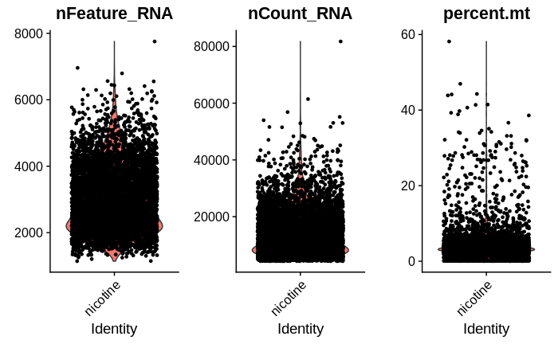

```r
obj[["percent.mt"]] <- PercentageFeatureSet(obj, pattern = "^MT-")
VlnPlot(obj, features = c("nFeature_RNA", "nCount_RNA", "percent.mt"), ncol = 3)
```

## Mitochondria and expressed genes

```r
obj <- subset(obj, subset = nFeature_RNA > 200 & nFeature_RNA < 6000 & percent.mt < 20)
obj
```

```
An object of class Seurat
33694 features across 5514 samples within 1 assay
Active assay: RNA (33694 features)
```

## Normalization

“We next normalized the gene expression values for each cell by the total expression, multiplied by 10,000, and made a log-transformation.” This is done by `NormalizeData`.

```r
obj <- NormalizeData(obj)
```

## Variable genes

Variable expressed genes across the single cells under cutoff with an average expression of more than 0.0125 and less than 3, and dispersion of more than 0.5, were detected for down-stream analysis.

```r
obj <- FindVariableFeatures(obj, mean.cutoff = c(0.0125, 3), dispersion.cutoff = c(0.5, Inf))
```

## Cell cycle

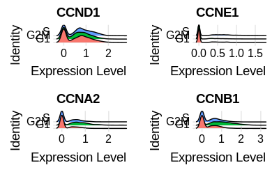

```r
obj <- CellCycleScoring(obj, s.features = cc.genes$s.genes, g2m.features = cc.genes$g2m.genes, set.ident = TRUE)
RidgePlot(obj, features = c("CCND1", "CCNE1", "CCNA2", "CCNB1"), ncol = 2)
```

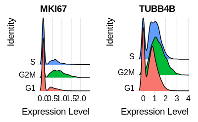

```r
RidgePlot(obj, features = c("MKI67", "TUBB4B"), ncol = 2)
```